# Goes using the oversampling method make any sense?

When we have a very unbalanced set, each classification model is good - that is, it has excellent parameters. Unfortunately, it depends on whether it classifies a collector's collection or not. Today we will check whether the application of oversampling is an effective method. Starting this experiment today I had mixed experiences. I do not know what will come out we start the experiment.

```python
import pandas as pd
import numpy as np
import seaborn as sns
import matplotlib.pyplot as plt
import warnings
from sklearn.ensemble import BaggingClassifier
from simple_colors import *
from prettytable import PrettyTable

warnings.filterwarnings("ignore")

%matplotlib inline

df= pd.read_csv('/home/wojciech/Pulpit/1/Stroke_Prediction.csv')
print(df.shape)
print()
print(df.columns)
df.head(3)
```

```
(43400, 12)

Index(['ID', 'Gender', 'Age_In_Days', 'Hypertension', 'Heart_Disease',
       'Ever_Married', 'Type_Of_Work', 'Residence', 'Avg_Glucose', 'BMI',
       'Smoking_Status', 'Stroke'],
      dtype='object')
```

|  | ID | Gender | Age_In_Days | Hypertension | Heart_Disease | Ever_Married | Type_Of_Work | Residence | Avg_Glucose | BMI | Smoking_Status | Stroke |
| --- | --- | --- | --- | --- | --- | --- | --- | --- | --- | --- | --- | --- |
| 0 | 31153 | Male | 1104.0 | 0 | 0 | No | children | Rural | 95.12 | 18.0 | NaN | 0 |
| 1 | 30650 | Male | 21204.0 | 1 | 0 | Yes | Private | Urban | 87.96 | 39.2 | never smoked | 0 |
| 2 | 17412 | Female | 2928.0 | 0 | 0 | No | Private | Urban | 110.89 | 17.6 | NaN | 0 |

Zmniejszacz próbki

```python
df = df.sample(frac = 1.0, random_state=10)
df.shape
```

```
(43400, 12)
```

### Tool for automatic coding of discrete variables

[figure not shown]

```python
a,b = df.shape     #<- ile mamy kolumn
b

print('DISCRETE FUNCTIONS CODED')
print('------------------------')
for i in range(1,b):
    i = df.columns[i]
    f = df[i].dtypes
    if f == np.object:
        print(i,"---",f)

        if f == np.object:

            df[i] = pd.Categorical(df[i]).codes

            continue
```

```
DISCRETE FUNCTIONS CODED
------------------------
Gender --- object
Ever_Married --- object
Type_Of_Work --- object
Residence --- object
Smoking_Status --- object
```

```python
df.fillna(7777, inplace=True)
```

```python
X = df.drop('Stroke', axis=1)
y = df['Stroke']

from sklearn.model_selection import train_test_split
X_train, X_test, y_train, y_test = train_test_split(X, y, test_size=0.20, random_state=123,stratify=y)
```

# Oversampling

[figure not shown]

```python
def oversampling(ytrain, Xtrain):
    import matplotlib.pyplot as plt

    global Xtrain_OV
    global ytrain_OV

    calss1 = np.round((sum(ytrain == 1)/(sum(ytrain == 0)+sum(ytrain == 1))),decimals=2)*100
    calss0 = np.round((sum(ytrain == 0)/(sum(ytrain == 0)+sum(ytrain == 1))),decimals=2)*100

    print("y = 0: ", sum(ytrain == 0),'-------',calss0,'%')
    print("y = 1: ", sum(ytrain == 1),'-------',calss1,'%')
    print('--------------------------------------------------------')

    ytrain.value_counts(dropna = False, normalize=True).plot(kind='pie',title='Before oversampling')
    plt.show
    print()

    Proporcja = sum(ytrain == 0) / sum(ytrain == 1)
    Proporcja = np.round(Proporcja, decimals=0)
    Proporcja = Proporcja.astype(int)

    ytrain_OV = pd.concat([ytrain[ytrain==1]] * Proporcja, axis = 0)
    Xtrain_OV = pd.concat([Xtrain.loc[ytrain==1, :]] * Proporcja, axis = 0)

    ytrain_OV = pd.concat([ytrain, ytrain_OV], axis = 0).reset_index(drop = True)
    Xtrain_OV = pd.concat([Xtrain, Xtrain_OV], axis = 0).reset_index(drop = True)

    Xtrain_OV = pd.DataFrame(Xtrain_OV)
    ytrain_OV = pd.DataFrame(ytrain_OV)



    print("Before oversampling Xtrain:     ", Xtrain.shape)
    print("Before oversampling ytrain:     ", ytrain.shape)
    print('--------------------------------------------------------')
    print("After oversampling Xtrain_OV:  ", Xtrain_OV.shape)
    print("After oversampling ytrain_OV:  ", ytrain_OV.shape)
    print('--------------------------------------------------------')


    ax = plt.subplot(1, 2, 1)
    ytrain.value_counts(dropna = False, normalize=True).plot(kind='pie',title='Before oversampling')
    plt.show


    kot = pd.concat([ytrain[ytrain==1]] * Proporcja, axis = 0)
    kot = pd.concat([ytrain, kot], axis = 0).reset_index(drop = True)
    ax = plt.subplot(1, 2, 2)
    kot.value_counts(dropna = False, normalize=True).plot(kind='pie',title='After oversampling')
    plt.show
```

```
y = 0:  34094 ------- 98.0 %
y = 1:  626 ------- 2.0 %
--------------------------------------------------------

Before oversampling Xtrain:      (34720, 11)
Before oversampling ytrain:      (34720,)
--------------------------------------------------------
After oversampling Xtrain_OV:   (68524, 11)
After oversampling ytrain_OV:   (68524, 1)
--------------------------------------------------------
```

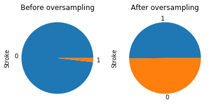

```python
oversampling(y_train, X_train)
```

[figure not shown]

I get rid of one dimension from the ytrain_OV set so that the set is similar to y_test.

```python
print(Xtrain_OV.shape)
print(ytrain_OV.shape)
ytrain_OV = ytrain_OV['Stroke']
print(ytrain_OV.shape)
```

```
(68524, 11)
(68524, 1)
(68524,)
```

```python
from sklearn.naive_bayes import GaussianNB
from sklearn.linear_model import LogisticRegression
from sklearn.ensemble import GradientBoostingClassifier
from sklearn.ensemble import RandomForestClassifier
from lightgbm import LGBMClassifier
from sklearn.ensemble import RandomForestClassifier
from catboost import CatBoostClassifier
from sklearn.svm import SVC
from sklearn.linear_model import LassoCV



NBC = GaussianNB()
LRE = LogisticRegression(solver='lbfgs')
GBC = GradientBoostingClassifier()
RFC = RandomForestClassifier()
LGBM = LGBMClassifier()
CBC = CatBoostClassifier(verbose=0, n_estimators=100)


classifiers_A = [NBC,LRE,GBC,RFC,LGBM,CBC]
name = ['NBC','LRE','GBC','RFC','LGBM','CBC']

#for cls in classifiers_A:
#    cls.fit(X_train, y_train)

classifiers_OV = [NBC,LRE,GBC,RFC,LGBM,CBC]
name2 = ['NBC_OV','LRE_OV','GBC_OV','RFC_OV','LGBM_OV','CBC_OV']

#for t in classifiers_OV:
#    t.fit(Xtrain_OV, ytrain_OV)
```

```python
def Recall_Precision(six_classifiers,name, X_train, y_train,X_test,y_test):

    import numpy as np
    import matplotlib.pyplot as plt
    from sklearn import metrics
    from sklearn.metrics import classification_report, confusion_matrix
    from sklearn.metrics import confusion_matrix, log_loss, auc, roc_curve, roc_auc_score, recall_score, precision_recall_curve
    from sklearn.metrics import make_scorer, precision_score, fbeta_score, f1_score, classification_report
    from sklearn.metrics import accuracy_score
    from mlxtend.plotting import plot_learning_curves
    from prettytable import PrettyTable
    #from simple_colors import *

    for cls in six_classifiers:
        cls.fit(X_train, y_train)


    Recall_Training = ['Recall Training: ']
    Precision_Training = ['Precision Training: ']
    Recall_Test= ['Recall Test: ']
    Precision_Test = ['Precision Test: ']

    def compute_metric2(model):

        Recall_Training = np.round(recall_score(y_train, model.predict(X_train)), decimals=3)
        Precision_Training = np.round(precision_score(y_train, model.predict(X_train)), decimals=3)
        Recall_Test = np.round(recall_score(y_test, model.predict(X_test)), decimals=3)
        Precision_Test = np.round(precision_score(y_test, model.predict(X_test)), decimals=3)

        return Recall_Training, Precision_Training, Recall_Test, Precision_Test

    for cls in six_classifiers:

        results = compute_metric2(cls)
        Recall_Training.append(results[0])
        Precision_Training.append(results[1])
        Recall_Test.append(blue(results[2],'bold'))
        Precision_Test.append((blue(results[3],'bold')))


    t = PrettyTable(['Name', name[0],name[1],name[2],name[3],name[4],name[5]])
    t.add_row(Recall_Training)
    t.add_row(Precision_Training)
    t.add_row(Recall_Test)
    t.add_row(Precision_Test)

    print(t)
    print(green('RECALL - procentowy udział chorych dobrze zdiagnozowanych w populacji ludzi chorych ogółem','italic'))
    print(green('PRECISION - procentowy udział chorych dobrze zdiagnozowanych w populacji ludzi zdiagnozowanyc fałszywie lub prawdziwie jako chorych','italic'))
```

In confusuin_matrix we have 4 states to consider. These values are presented in the form of a matrix in which the Y axis shows the real classes, while the X axis shows the predicted classes. Because we are considering a medical case, let's imagine that we are analyzing if someone has COVID-19.

In confusuin_matrix we have 4 states to consider. These values are presented in the form of a matrix in which the Y axis shows the real classes, while the X axis shows the predicted classes. Because we are considering a medical case, let's imagine that we are analyzing if someone has COVID-19.

After balancing the classes by applying oversampling, the COVID-19 detection level has improved significantly. For the aforementioned LogisticRegression model, the model detected 121 patients out of 157 possible (True-Negative). However, he scared 3701 people saying that they have COVID even though they were healthy, i.e. this model caught the patients (True-Negative) while it indicated 3701 as sick although they were healthy, there were 8523 healthy (type I error). Normally, the model would fly far out the window. The discussed LogisticRegression model also found 36 patients healthy (type II error) after oversampling, i.e. it caused further infections, because these people went to work normally. the other models did better, but the results after oversampling are still not satisfactory.

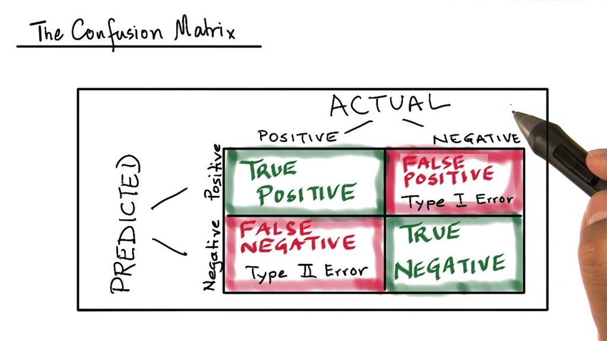

W confusuin_matrix mamy 4 stany do rozważenia. Wartości te są przedstawione w postaci macierzy, w której oś Y pokazuje prawdziwe klasy, podczas gdy oś X pokazuje przewidywane klasy. Ponieważ rozpatrujemy przypadek medyczny wyobraźmy sobie, że analizujemy czy ktoś jest chory na COVID-19.

Po zbilansowaniu klas przez zastosowanie oversampling poziom wykrywalności COVID-19 znacznie się poprawił. Dla wspomnianego modelu LogisticRegression model wykrył 121 chorych na 157 możliwych (True-Negative). Natomiast wystraszył 3701 osób mówiąc że mają COVID mimo, że byli zdrowi, czyli ten model wyłapał chorych (True-Negative) natomiast wskazał, 3701 jako chorych mimo, że byli zdrowi, zdrowych łącznie było 8523 (bład I typu). W normalnej sytuacji model wyleciałby daleko za okno. Omawiany model LogisticRegression po oversampling uznał też 36 chorych za zdrowych (błąd II typu) czyli przysporzył kolejnych zarażeń, bo ludzie ci poszli normalnie do pracy. pozostałe modele lepiej poroadziły sobie lecz wyniki po oversampling wciąż nie należą do zadowalających.

```python
y_test.value_counts()
```

```
0    8523
1     157
Name: Stroke, dtype: int64
```

```python
def confusion_matrix(six_classifiers,name, X_train, y_train,X_test,y_test):

    from sklearn.metrics import plot_confusion_matrix

    for cls in six_classifiers:
        cls.fit(X_train, y_train)

    fig, axes = plt.subplots(nrows=2, ncols=3, figsize=(14,7))
    target_names = ['0','1']


    for cls, ax in zip(six_classifiers, axes.flatten()):
        plot_confusion_matrix(cls,
                              X_test,
                              y_test,
                              ax=ax,
                              cmap='Blues',
                             display_labels=target_names,values_format='')
        ax.title.set_text(type(cls).__name__)
        ax.title.set_color('blue')

    plt.tight_layout()
    plt.show()
```

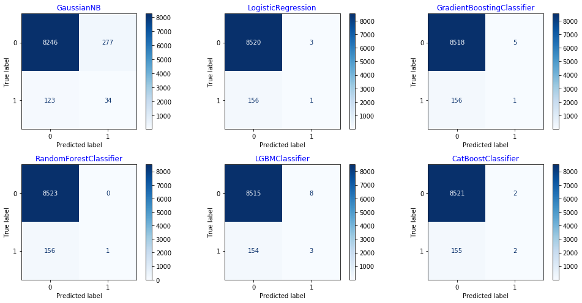

```python
confusion_matrix(classifiers_A,name, X_train, y_train,X_test,y_test)
```

### After oversampling

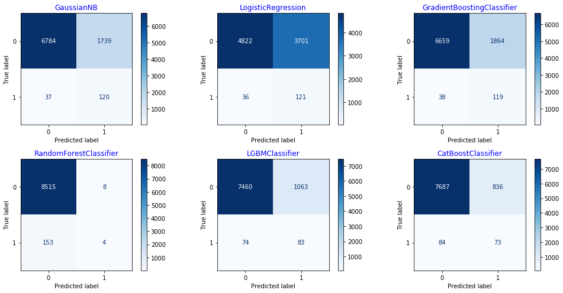

```python
confusion_matrix(classifiers_OV,name2, Xtrain_OV, ytrain_OV,X_test,y_test)
```

### Recall przed oversampling

W naszym przykładzie Recall oznacza odsetek chorych, u których rozpoznano chorobę (true-positive) z pośród wszytkich chorych.

$ Recall = \displaystyle\frac{tp}{tp+fn} $

Bez oversampling mamy bardzo niezbilansowane klasy, w naszym przypadku zdrowi oznaczeni jako 0 stanowią 98% populacji zaś chorzy oznaczeni jako 1 stanowi zaledwie 2% populacji. Poziom Ricall dla modelu GaussianNB oblicza się ze wzoru:

$ Recall = \displaystyle\frac{34}{34+123}=0.217 $

Jak widać Recall pokazuje jaki procent chorych wskazał model jako chorych z pośród wszystkich chorych. Bez oversampling, przy mocno niezbilansowanym zbiorze wynik jest bardzo zły.

### Recall po oversampling

Po zbilansowaniu próby przez oversampling otrzymaliśmy znacznie lepsze wyniki recall. Dla modelu GaussianNB wynik ten wyniósł:

$ Recall = \displaystyle\frac{120}{120+37}=0.764 $

### Precission przed oversampling

$ Precision = \displaystyle\frac{tp}{tp+fp} $

Przed oversampling winik precision dla modelu GaussianNB bedzie wynosił:

$ Precision = \displaystyle\frac{34}{34+277} = 0.109$

Dla modelu LogisticRegression:

$ Precision = \displaystyle\frac{1}{1+3} = 0.25$

### Precission po oversampling

Dla modelu GaussianNB:

$ Precision = \displaystyle\frac{120}{120+1739} = 0.064$

Dla modelu LogisticRegression:

$ Precision = \displaystyle\frac{121}{121+3701} = 0.032$

Czyli modele są dalej beznadziejne. Wyobraźmy sobie przychodnie zdrowia, w której testy wskazały chorych na COVID-19. Jednak potam okazało sie, że na stu pacjętów jedynie 6% pacjętów było naprawde zarażonych wirusem. Oversampling nie pomógł we wskaźniku precision. Oversampling spowodował znaczny wzrost czułości modeli.

I jeszcze jedno: Zwiększenie recall powoduje zmniejszenie precission co zobaczymy na wykresach w dalszej części opracowania.

```python
Recall_Precision(classifiers_A,name,X_train, y_train,X_test,y_test)
```

```
+----------------------+-------+-------+-------+-------+-------+-------+
|         Name         |  NBC  |  LRE  |  GBC  |  RFC  |  LGBM |  CBC  |
+----------------------+-------+-------+-------+-------+-------+-------+
|  Recall Training:    | 0.196 | 0.003 | 0.032 | 0.998 |  0.22 | 0.072 |
| Precision Training:  | 0.104 | 0.118 |  0.87 |  1.0  | 0.986 | 0.938 |
|    Recall Test:      | 0.217 | 0.006 | 0.006 | 0.006 | 0.019 | 0.013 |
|   Precision Test:    | 0.109 |  0.25 |  0.2  |  1.0  | 0.273 |  0.5  |
+----------------------+-------+-------+-------+-------+-------+-------+
RECALL - procentowy udział chorych dobrze zdiagnozowanych w populacji ludzi chorych ogółem
PRECISION - procentowy udział chorych dobrze zdiagnozowanych w populacji ludzi zdiagnozowanyc fałszywie lub prawdziwie jako chorych
```

```python
Recall_Precision(classifiers_OV,name2,Xtrain_OV, ytrain_OV,X_test,y_test)
```

```
+----------------------+--------+--------+--------+--------+---------+--------+
|         Name         | NBC_OV | LRE_OV | GBC_OV | RFC_OV | LGBM_OV | CBC_OV |
+----------------------+--------+--------+--------+--------+---------+--------+
|  Recall Training:    | 0.762  | 0.791  | 0.874  |  1.0   |  0.994  | 0.998  |
| Precision Training:  | 0.789  | 0.645  |  0.8   |  1.0   |  0.896  | 0.923  |
|    Recall Test:      | 0.764  | 0.771  | 0.758  | 0.019  |  0.529  | 0.465  |
|   Precision Test:    | 0.065  | 0.032  |  0.06  | 0.333  |  0.072  |  0.08  |
+----------------------+--------+--------+--------+--------+---------+--------+
RECALL - procentowy udział chorych dobrze zdiagnozowanych w populacji ludzi chorych ogółem
PRECISION - procentowy udział chorych dobrze zdiagnozowanych w populacji ludzi zdiagnozowanyc fałszywie lub prawdziwie jako chorych
```

```python
def classification_score(six_classifiers,name, X_train, y_train,X_test,y_test):

    from sklearn.metrics import precision_recall_fscore_support as score

    Precision_0 = ['Precision_0: ']
    Precision_1 = ['Precision_1: ']
    Recall_0 = ['Recall_0: ']
    Recall_1 = ['Recall_1: ']
    f1_score_0 = ['f1-score_0: ']
    f1_score_1 = ['f1-score_1: ']
    Support_0 = ['Support_0: ']
    Support_1 = ['Support_1: ']

    for cls in six_classifiers:
        cls.fit(X_train, y_train)


    def compute_metric4(model):

        precision, recall, fscore, support = score(y_test, model.predict(X_test))

        Precision_0 = np.round(precision[:1],decimals=3).item()
        Precision_1 = np.round(precision[1:],decimals=3).item()
        Recall_0 = np.round(recall[:1],decimals=3).item()
        Recall_1 = np.round(recall[1:],decimals=3).item()
        f1_score_0 = np.round(fscore[:1],decimals=3).item()
        f1_score_1 = np.round(fscore[1:],decimals=3).item()
        Support_0 = np.round(support[:1],decimals=3).item()
        Support_1 = np.round(support[1:],decimals=3).item()

        return Precision_0, Precision_1, Recall_0, Recall_1, f1_score_0, f1_score_1, Support_0, Support_1

    for cls in six_classifiers:

        results = compute_metric4(cls)
        Precision_0.append(results[0])
        Precision_1.append(blue(results[1],'bold'))
        Recall_0.append(results[2])
        Recall_1.append(blue(results[3],'bold'))
        f1_score_0.append(results[4])
        f1_score_1.append(blue(results[5],'bold'))
        Support_0.append(results[6])
        Support_1.append(blue(results[7],'bold'))


    t = PrettyTable(['Name', name[0],name[1],name[2],name[3],name[4],name[5]])
    t.add_row(Precision_0)
    t.add_row(Precision_1)
    t.add_row(Recall_0)
    t.add_row(Recall_1)
    t.add_row(f1_score_0)
    t.add_row(f1_score_1)
    t.add_row(Support_0)
    t.add_row(Support_1)


    print(t)
    print(green('RECALL - procentowy udział chorych dobrze zdiagnozowanych w populacji ludzi chorych ogółem','italic'))
    print(green('PRECISION - procentowy udział chorych dobrze zdiagnozowanych w populacji ludzi zdiagnozowanyc fałszywie lub prawdziwie jako chorych','italic'))
```

## Analiza recall - precision dla osób zdrowych

In our example, we examine the quality of the classification for the detection of COVID_19 patients. It is less important to say that healthy people are really healthy. Due to the fact that only 2% of patients are sick, even if they consider everyone (even the sick) to be healthy, they will have a high recall and a very high precision ratio. Such information does not lead to anything, below are the calculations for healthy for the GaussianNB model.

W naszym przykładzie badamy jakość kalsyfikacji dla wykrywania chorych na COVID_19. Mniejsze znaczenie ma stwierdzdenie, że zdrowi są naprawde zdrowi. Przez to, że chorych jest zaledwie 2%, modele nawet jak uznają wszystkich (nawet chorych) za zdrowych będą miały wysoki recall i bardzo wysoki wskaźnik precision. Taka informacja do niczego nie prowadzi, poniżej znajdują się kalkulacje dla zdrowych dla modelu GaussianNB.

### Przed oversampling dla modelu GaussianNB:

$ Precision = \displaystyle\frac{8246}{8246+123} = 0.985$

```python
from sklearn.metrics import confusion_matrix

NBC = NBC.fit(X_train,y_train)
confusion_matrix(y_test, NBC.predict(X_test))
```

```
array([[8246,  277],
       [ 123,   34]])
```

### Po oversampling dla modelu GaussianNB:

$ Precision = \displaystyle\frac{6784}{6784+37} = 0.995$

```python
from sklearn.metrics import confusion_matrix

NBC_OV = NBC.fit(Xtrain_OV, ytrain_OV)
confusion_matrix(y_test, NBC_OV.predict(X_test))
```

```
array([[6784, 1739],
       [  37,  120]])
```

```python
classification_score(classifiers_A,name, X_train, y_train,X_test,y_test)
```

```
+---------------+-------+-------+-------+-------+-------+-------+
|      Name     |  NBC  |  LRE  |  GBC  |  RFC  |  LGBM |  CBC  |
+---------------+-------+-------+-------+-------+-------+-------+
| Precision_0:  | 0.985 | 0.982 | 0.982 | 0.982 | 0.982 | 0.982 |
| Precision_1:  | 0.109 |  0.25 |  0.2  |  1.0  | 0.273 |  0.5  |
|   Recall_0:   | 0.967 |  1.0  |  1.0  |  1.0  | 0.999 |  1.0  |
|   Recall_1:   | 0.217 | 0.006 | 0.006 | 0.006 | 0.019 | 0.013 |
|  f1-score_0:  | 0.976 | 0.991 | 0.991 | 0.991 | 0.991 | 0.991 |
|  f1-score_1:  | 0.145 | 0.012 | 0.012 | 0.013 | 0.036 | 0.025 |
|  Support_0:   |  8523 |  8523 |  8523 |  8523 |  8523 |  8523 |
|  Support_1:   |  157  |  157  |  157  |  157  |  157  |  157  |
+---------------+-------+-------+-------+-------+-------+-------+
RECALL - procentowy udział chorych dobrze zdiagnozowanych w populacji ludzi chorych ogółem
PRECISION - procentowy udział chorych dobrze zdiagnozowanych w populacji ludzi zdiagnozowanyc fałszywie lub prawdziwie jako chorych
```

```python
classification_score(classifiers_OV,name2,Xtrain_OV, ytrain_OV,X_test,y_test)
```

```
+---------------+--------+--------+--------+--------+---------+--------+
|      Name     | NBC_OV | LRE_OV | GBC_OV | RFC_OV | LGBM_OV | CBC_OV |
+---------------+--------+--------+--------+--------+---------+--------+
| Precision_0:  | 0.995  | 0.993  | 0.994  | 0.982  |   0.99  | 0.989  |
| Precision_1:  | 0.065  | 0.032  |  0.06  |  0.5   |  0.072  |  0.08  |
|   Recall_0:   | 0.796  | 0.566  | 0.781  | 0.999  |  0.875  | 0.902  |
|   Recall_1:   | 0.764  | 0.771  | 0.758  | 0.032  |  0.529  | 0.465  |
|  f1-score_0:  | 0.884  | 0.721  | 0.875  | 0.991  |  0.929  | 0.944  |
|  f1-score_1:  | 0.119  | 0.061  | 0.111  |  0.06  |  0.127  | 0.137  |
|  Support_0:   |  8523  |  8523  |  8523  |  8523  |   8523  |  8523  |
|  Support_1:   |  157   |  157   |  157   |  157   |   157   |  157   |
+---------------+--------+--------+--------+--------+---------+--------+
RECALL - procentowy udział chorych dobrze zdiagnozowanych w populacji ludzi chorych ogółem
PRECISION - procentowy udział chorych dobrze zdiagnozowanych w populacji ludzi zdiagnozowanyc fałszywie lub prawdziwie jako chorych
```

Miara f1 jest miarą łaczącą precision i recall. Jet to w przybliżeniu średni z tych dwóch wskaźników.

$ F1 = 2\times\displaystyle\frac{precision\times{recall}}{precision+{recall}} $

Przed oversampling dla modelu GaussianNB dla klasy 1:

$ F1 = 2\times\displaystyle\frac{0.109\times{0.217}}{0.109+{0.217}}= 0.1451$

Po oversampling dla modelu GaussianNB dla klasy 1:

$ F1 = 2\times\displaystyle\frac{0.065\times{0.764}}{0.065+{0.764}}= 0.1198$

Jak widać dla modelu GaussianNB zastosowanie oversampling pogorszył wynik wskaźnika F1.

```python
def AUC_score(six_classifiers,name, X_train, y_train,X_test,y_test):

    from sklearn import metrics

    for cls in six_classifiers:
        cls.fit(X_train, y_train)


    AUC_train = ['AUC_train: ']
    AUC_test = ['AUC_test: ']

    def compute_metric(model):

        auc_train = np.round(metrics.roc_auc_score(y_train,model.predict_proba(X_train)[:,1]),decimals=3)
        auc_test = np.round(metrics.roc_auc_score(y_test,model.predict_proba(X_test)[:,1]),decimals=3)

        return auc_train, auc_test

    for cls in six_classifiers:

        results = compute_metric(cls)
        AUC_train.append(results[0])
        AUC_test.append(results[1])


    t = PrettyTable(['Name', name[0],name[1],name[2],name[3],name[4],name[5]])
    t.add_row(AUC_train)
    t.add_row(AUC_test)

    print(t)
```

```python
AUC_score(classifiers_A,name, X_train, y_train,X_test,y_test)
```

```
+-------------+-------+-------+-------+-------+-------+-------+
|     Name    |  NBC  |  LRE  |  GBC  |  RFC  |  LGBM |  CBC  |
+-------------+-------+-------+-------+-------+-------+-------+
| AUC_train:  | 0.849 | 0.662 | 0.901 |  1.0  |  0.99 |  0.92 |
|  AUC_test:  | 0.853 | 0.627 | 0.862 | 0.816 | 0.844 | 0.852 |
+-------------+-------+-------+-------+-------+-------+-------+
```

```python
AUC_score(classifiers_OV,name2, Xtrain_OV, ytrain_OV,X_test,y_test)
```

```
+-------------+--------+--------+--------+--------+---------+--------+
|     Name    | NBC_OV | LRE_OV | GBC_OV | RFC_OV | LGBM_OV | CBC_OV |
+-------------+--------+--------+--------+--------+---------+--------+
| AUC_train:  | 0.849  | 0.756  | 0.909  |  1.0   |  0.985  | 0.989  |
|  AUC_test:  | 0.853  |  0.75  | 0.852  | 0.817  |  0.832  | 0.804  |
+-------------+--------+--------+--------+--------+---------+--------+
```

```python
def Accuracy_score(six_classifiers,name, X_train, y_train,X_test,y_test):

    from sklearn.metrics import accuracy_score

    for cls in six_classifiers:
        cls.fit(X_train, y_train)


    Accuracy_Training = ['Accuracy_Training: ']
    Accuracy_Test = ['Accuracy_Test: ']

    def compute_metric5(model):

        Accuracy_Training = np.round(accuracy_score(y_train, model.predict(X_train)), decimals=3)
        Accuracy_Test = np.round(accuracy_score(y_test, model.predict(X_test)), decimals=3)

        return  Accuracy_Training, Accuracy_Test

    for cls in six_classifiers:

        results = compute_metric5(cls)
        Accuracy_Training.append(results[0])
        Accuracy_Test.append(results[1])


    t = PrettyTable(['Name', 'GN','LogReg','GradBoos','RandFor','LGBM','CatBoost'])
    t.add_row(Accuracy_Training)
    t.add_row(Accuracy_Test)

    print(t)
```

```python
Accuracy_score(classifiers_A,name, X_train, y_train,X_test,y_test)
```

```
+---------------------+-------+--------+----------+---------+-------+----------+
|         Name        |   GN  | LogReg | GradBoos | RandFor |  LGBM | CatBoost |
+---------------------+-------+--------+----------+---------+-------+----------+
| Accuracy_Training:  | 0.955 | 0.982  |  0.982   |   1.0   | 0.986 |  0.983   |
|   Accuracy_Test:    | 0.954 | 0.982  |  0.981   |  0.982  | 0.981 |  0.982   |
+---------------------+-------+--------+----------+---------+-------+----------+
```

```python
Accuracy_score(classifiers_OV,name2, Xtrain_OV, ytrain_OV,X_test,y_test)
```

```
+---------------------+-------+--------+----------+---------+-------+----------+
|         Name        |   GN  | LogReg | GradBoos | RandFor |  LGBM | CatBoost |
+---------------------+-------+--------+----------+---------+-------+----------+
| Accuracy_Training:  | 0.778 | 0.676  |  0.827   |   1.0   | 0.939 |  0.957   |
|   Accuracy_Test:    | 0.795 | 0.569  |  0.781   |  0.982  | 0.869 |  0.894   |
+---------------------+-------+--------+----------+---------+-------+----------+
```

```python
def f1_score(six_classifiers,name, X_train, y_train,X_test,y_test):

    from sklearn import metrics
    from sklearn.metrics import make_scorer, precision_score, fbeta_score, f1_score, classification_report

    for cls in six_classifiers:
        cls.fit(X_train, y_train)

    classifiers = [NBC,LRE,GBC,RFC,LGBM,CBC]
    f1_score_macro = ['f1_score_macro:  ']
    f1_score_micro = ['f1_score_micro: ']

    def compute_metric6(model):

        f1_score_macro = np.round(metrics.f1_score(y_test, model.predict(X_test), average='macro'), decimals=3)
        f1_score_micro = np.round(metrics.f1_score(y_test, model.predict(X_test), average='micro'), decimals=3)

        return  f1_score_macro, f1_score_micro

    for cls in six_classifiers:

        results = compute_metric6(cls)
        f1_score_macro.append(results[0])
        f1_score_micro.append(results[1])


    t = PrettyTable(['Name', 'GN','LogReg','GradBoos','RandFor','LGBM','CatBoost'])
    t.add_row(f1_score_macro)
    t.add_row(f1_score_micro)

    print(t)
```

```python
f1_score(classifiers_A,name, X_train, y_train,X_test,y_test)
```

```
+-------------------+-------+--------+----------+---------+-------+----------+
|        Name       |   GN  | LogReg | GradBoos | RandFor |  LGBM | CatBoost |
+-------------------+-------+--------+----------+---------+-------+----------+
| f1_score_macro:   | 0.561 | 0.502  |  0.502   |  0.502  | 0.513 |  0.508   |
|  f1_score_micro:  | 0.954 | 0.982  |  0.982   |  0.982  | 0.981 |  0.982   |
+-------------------+-------+--------+----------+---------+-------+----------+
```

```python
f1_score(classifiers_OV,name2, Xtrain_OV, ytrain_OV,X_test,y_test)
```

```
+-------------------+-------+--------+----------+---------+-------+----------+
|        Name       |   GN  | LogReg | GradBoos | RandFor |  LGBM | CatBoost |
+-------------------+-------+--------+----------+---------+-------+----------+
| f1_score_macro:   | 0.502 | 0.391  |  0.493   |  0.519  | 0.528 |   0.54   |
|  f1_score_micro:  | 0.795 | 0.569  |  0.781   |  0.982  | 0.869 |  0.894   |
+-------------------+-------+--------+----------+---------+-------+----------+
```

https://neptune.ai/blog/evaluation-metrics-binary-classification

## False Positive Rate ( type I error)

Błąd powstaje kiedy przewidujemy coś, gdy tego nie ma. W naszym przykładzie będzie to ilość ludzi zdrowych uznanych przez model za chorych w stosunku do wszystkich zdrowych w populacji. Czyli procentowy udział ludzi zdrowych źle zdiagnozowanych w zbiorowisku ludzi zdrowych. Czym mniejszy jest ten udział tym lepiej!

False Positive Rate można wyliczyć ze wzoru:

$ False Positive Rate = \displaystyle\frac{fp}{fp+tn}$

Przed oversampling dla modelu GaussianNB dla klasy 1:

$ False Positive Rate = \displaystyle\frac{277}{277+8246}=0.0325$

Po oversampling dla modelu GaussianNB dla klasy 1:

$ False Positive Rate = \displaystyle\frac{1739}{1739+6784}=0.2040$

$\begin{matrix} tn & fp \\ fn & tp \end{matrix}$

To samo można obliczyć za pomocą funkcji:

```python
from sklearn.metrics import confusion_matrix

NBC = NBC.fit(X_train,y_train)
cm = confusion_matrix(y_test, NBC.predict(X_test))
tn, fp, fn, tp = cm.ravel()
print('tn: ',tn)
print('fp: ',fp)
print('fn: ',fn)
print('tp: ',tp)
print('------------------')
print(cm)
```

```
tn:  8246
fp:  277
fn:  123
tp:  34
------------------
[[8246  277]
 [ 123   34]]
```

```python
false_positive_rate = fp / (fp + tn)
false_positive_rate
```

```
0.032500293323946966
```

```python
NBC_OV = NBC.fit(Xtrain_OV,ytrain_OV)
cm_ov = confusion_matrix(y_test, NBC_OV.predict(X_test))
tn, fp, fn, tp = cm_ov.ravel()
print('tn: ',tn)
print('fp: ',fp)
print('fn: ',fn)
print('tp: ',tp)
print('------------------')
print(cm_ov)
```

```
tn:  6784
fp:  1739
fn:  37
tp:  120
------------------
[[6784 1739]
 [  37  120]]
```

```python
false_positive_rate = fp / (fp + tn)
false_positive_rate
```

```
0.20403613751026634
```

## True Positive Rate (type II error) RECALL

W liczniku jest ilość chorych uznanych przez model za chorych. Wskaźnik mówi jaki jest procentowy udział chorych dobrze zdiagnozowanych w populacji ludzi chorych ogółem.

$ True Positive Rate = \displaystyle\frac{tp}{tp+fn}$

Przed oversampling dla modelu GaussianNB dla klasy 1:

$ True Positive Rate = \displaystyle\frac{34}{34+123} = 0.2165 $

Po oversampling dla modelu GaussianNB dla klasy 1:

$ True Positive Rate = \displaystyle\frac{120}{120+37} = 0.7643 $

```python
𝑇𝑟𝑢𝑒_𝑃𝑜𝑠𝑖𝑡𝑖𝑣𝑒_𝑅𝑎𝑡𝑒 = tp / (tp + fn)
𝑇𝑟𝑢𝑒_𝑃𝑜𝑠𝑖𝑡𝑖𝑣𝑒_𝑅𝑎𝑡𝑒
```

```
0.7643312101910829
```

## False Negative Rate (type II error)

Wskaźnik ten można zdefiniować jako procentowy udział niewykrytych chorych (fn) w badanej populacji. Czyli ilość niewykrytych chorych jest dzielona przez sume wszystkich faktycznie chorych. To coś w rodzaju recall lecz tu w liczbniku zamiast chorych wykrytych jest liczba chorych niewykrytych.

$ False Negative Rate = \displaystyle\frac{fn}{tp+fn}$

```python
from sklearn.metrics import confusion_matrix

NBC = NBC.fit(X_train,y_train)
cm = confusion_matrix(y_test, NBC.predict(X_test))
tn, fp, fn, tp = cm.ravel()
print('tn: ',tn)
print('fp: ',fp)
print('fn: ',fn)
print('tp: ',tp)
print('------------------')
print(cm)
```

```
tn:  8246
fp:  277
fn:  123
tp:  34
------------------
[[8246  277]
 [ 123   34]]
```

```python
False_Negative_Rate = fn/(tp+fn)
False_Negative_Rate
```

```
0.7834394904458599
```

## True Negative Rate (Specificity)

W naszym przykładzie wykrywania chorych COVID-19 pokazuje nam, ilu ludzi zdrowych procentowo spośród wszystkich zdrowych sklasyfikowano jako zdrowych. Jak wypada 80% to znaczy że 20% ludzi zdrowych zostało niepotrzebnie wystraszonych, że są chorzy.

$ Specificity = \displaystyle\frac{tn}{tn+fp}$

```python
def Type_error(six_classifiers,name, X_train, y_train,X_test,y_test):

    from sklearn import metrics
    import simple_colors

    for cls in six_classifiers:
        cls.fit(X_train, y_train)


    FPR = ['False_Positive_Rate:']
    TPR = ['True_Positive_Rate: ']
    FNR = ['False_Negative_Rate: ']
    SPEC = ['Specifity']

    def compute_metric(model):

        FPR = np.round(fp/(fp + tn),decimals=3)
        TPR = np.round(tp/(tp + fn),decimals=3)
        FNR = np.round(fn/(tp + fn),decimals=3)
        SPEC = np.round(tn/(tn + fp),decimals=3)

        return FPR,TPR,FNR,SPEC

    for cls in six_classifiers:

        cls.fit(X_train,y_train)
        cm = confusion_matrix(y_test, cls.predict(X_test))
        tn, fp, fn, tp = cm.ravel()

        kom =['1','2','3','4']


        results = compute_metric(cls)
        FPR.append(results[0])
        TPR.append(red(results[1],'bold'))
        FNR.append(results[2])
        SPEC.append(results[3])

    t = PrettyTable(['Name', name[0],name[1],name[2],name[3],name[4],name[5]])
    t.add_row(FPR)
    t.add_row(TPR)
    t.add_row(FNR)
    t.add_row(SPEC)

    print(t)

    print(black('False_Positive_Rate - procentowy udział ludzi zdrowych uznanych przez model za chorych w populacji ludzi zdrowych','italic'))
    print(red('True_Positive_Rate RECALL - procentowy udział chorych dobrze zdiagnozowanych w populacji ludzi chorych ogółem','italic'))
    print(black('False_Negative_Rate - procentowy udział niewykrytych chorych w populacji ludzi chorych ogółem','italic'))
    print(black('Specifity - procentowy udział ludzi zdrowych uznanych za zdrowych w populacji ludzi zdrowych','italic'))
```

```python
Type_error(classifiers_A,name, X_train, y_train,X_test,y_test)
```

```
+-----------------------+-------+-------+-------+-------+-------+-------+
|          Name         |  NBC  |  LRE  |  GBC  |  RFC  |  LGBM |  CBC  |
+-----------------------+-------+-------+-------+-------+-------+-------+
|  False_Positive_Rate: | 0.033 |  0.0  | 0.001 |  0.0  | 0.001 |  0.0  |
|  True_Positive_Rate:  | 0.217 | 0.006 | 0.006 | 0.006 | 0.019 | 0.013 |
| False_Negative_Rate:  | 0.783 | 0.994 | 0.994 | 0.994 | 0.981 | 0.987 |
|       Specifity       | 0.967 |  1.0  | 0.999 |  1.0  | 0.999 |  1.0  |
+-----------------------+-------+-------+-------+-------+-------+-------+
False_Positive_Rate - procentowy udział ludzi zdrowych uznanych przez model za chorych w populacji ludzi zdrowych
True_Positive_Rate RECALL - procentowy udział chorych dobrze zdiagnozowanych w populacji ludzi chorych ogółem
False_Negative_Rate - procentowy udział niewykrytych chorych w populacji ludzi chorych ogółem
Specifity - procentowy udział ludzi zdrowych uznanych za zdrowych w populacji ludzi zdrowych
```

Jak widać w zbiorze wysoko niezbilansowanym modele uznawały prawie wszystkich za zdrowych. Ogolnie efektywność modeli w wykrywaniu ludzi chorych była bardzo słaba (True_Positive_Rate). W najlepszym modelu NBC wykrywalność ludzi chorych wynosiła około 20%, w pozostałych modelach wykrywalność była bliska zeru. Przy bardzo niezbilansowanych zbiorach, mimo że model nie wykrył żadnego chorego, zachował bardzo wysoki wskażnik accuracy.

```python
Type_error(classifiers_OV,name2, Xtrain_OV, ytrain_OV,X_test,y_test)
```

```
+-----------------------+--------+--------+--------+--------+---------+--------+
|          Name         | NBC_OV | LRE_OV | GBC_OV | RFC_OV | LGBM_OV | CBC_OV |
+-----------------------+--------+--------+--------+--------+---------+--------+
|  False_Positive_Rate: | 0.204  | 0.434  | 0.219  | 0.001  |  0.125  | 0.098  |
|  True_Positive_Rate:  | 0.764  | 0.771  | 0.758  | 0.025  |  0.529  | 0.465  |
| False_Negative_Rate:  | 0.236  | 0.229  | 0.242  | 0.975  |  0.471  | 0.535  |
|       Specifity       | 0.796  | 0.566  | 0.781  | 0.999  |  0.875  | 0.902  |
+-----------------------+--------+--------+--------+--------+---------+--------+
False_Positive_Rate - procentowy udział ludzi zdrowych uznanych przez model za chorych w populacji ludzi zdrowych
True_Positive_Rate RECALL - procentowy udział chorych dobrze zdiagnozowanych w populacji ludzi chorych ogółem
False_Negative_Rate - procentowy udział niewykrytych chorych w populacji ludzi chorych ogółem
Specifity - procentowy udział ludzi zdrowych uznanych za zdrowych w populacji ludzi zdrowych
```

Po zbilansowaniu zbiorów za pomocą oversampling okazało modele zaczęły znacznie lepiej wykrywać ludzi chorych w populacji ludzi chorych (True_Positive_Rate). Model NBC posiada teraz wykrywalność rzędu 76%, przy okazji około 20% ludzi zdrowych model ten uznaje za chorych (False_Positive_Rate). Model LogisticRegresion ma podobną wykrywalność ludzi chorych co NBC na poziomie 77% niestety ma znacznie wyższy 43 procentowy udział określania ludzi zdrowych jako chorych (False_Positive_Rate).

### Binary Class Plot

```python
def BinaryClassPlot(six_classifiers,name, X_train, y_train,X_test,y_test):

    from plot_metric.functions import BinaryClassification

    for cls in six_classifiers:
        cls.fit(X_train, y_train)

    plt.figure(figsize=(15,7))
    grid = plt.GridSpec(2, 3, wspace=0.3, hspace=0.4)

    for i in range(6):
        col, row = i%3,i//3
        ax = plt.subplot(grid[row,col])
        ax.title.set_color('blue')

        model = six_classifiers[i]
        bc = BinaryClassification(y_test, model.predict_proba(X_test)[:,1], labels=["Class 1", "Class 2"])
        bc.plot_roc_curve(title=type(six_classifiers[i]).__name__)
```

Najbardziej na wykresie ROC AUC przyciąga uwagę czerwony punkt. Współczędne czerwonego punktu znajdują się na osi X i y. wspołczędne osi X to False Positive Rate. Punkt ten ma wsplrzędne dla X:False_Positive_Rate, y:True_Positive_Rate.

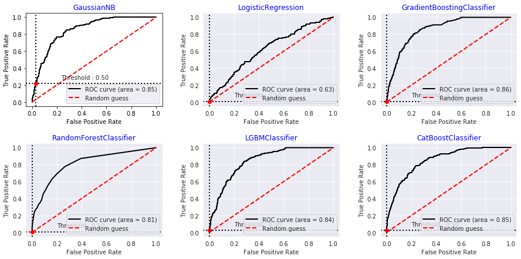

```python
BinaryClassPlot(classifiers_A,name, X_train, y_train,X_test,y_test)
```

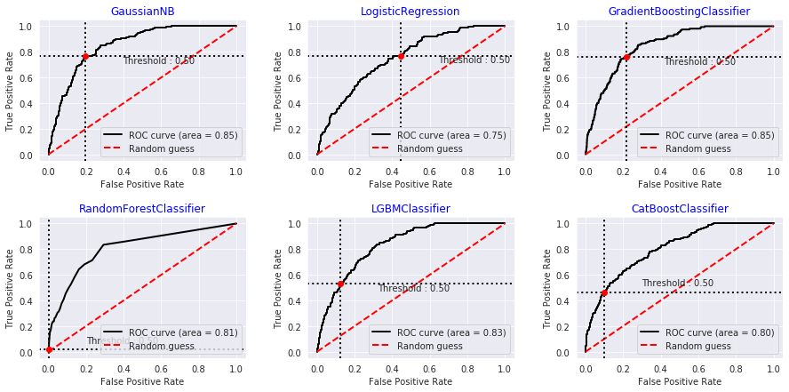

```python
BinaryClassPlot(classifiers_OV,name2, Xtrain_OV, ytrain_OV,X_test,y_test)
```

```python
def Precision_Recall_plot(six_classifiers,name, X_train, y_train,X_test,y_test):

    from sklearn.metrics import confusion_matrix, log_loss, auc, roc_curve, roc_auc_score, recall_score, precision_recall_curve

    for cls in six_classifiers:
        cls.fit(X_train, y_train)

    fig, axes = plt.subplots(nrows=2, ncols=3, figsize=(16,7))

    for cls, ax in zip(six_classifiers, axes.flatten()):
        precision, recall, thresholds = precision_recall_curve(y_test, cls.predict_proba(X_test)[:,1])
        ax.plot(recall, precision, marker='.', label='model')
        ax.title.set_text(type(cls).__name__)
        ax.title.set_color('blue')
        ax.set_xlabel('Recall', color='grey', alpha=0.8)
        ax.set_ylabel('Precision', color='grey', alpha=0.8)

    plt.tight_layout()
    plt.show()
```

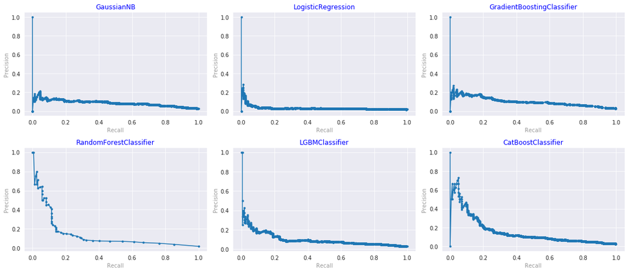

```python
Precision_Recall_plot(classifiers_A,name, X_train, y_train,X_test,y_test)
```

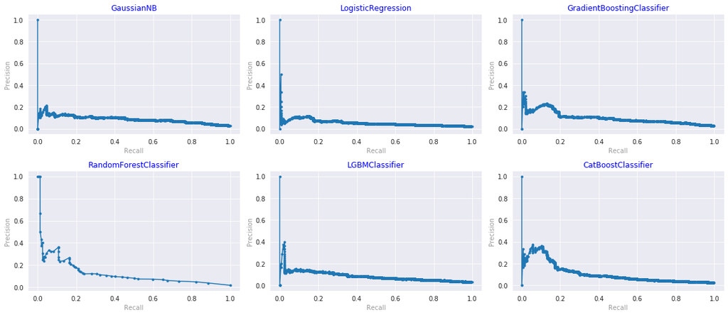

```python
Precision_Recall_plot(classifiers_OV,name2, Xtrain_OV, ytrain_OV,X_test,y_test)
```

## Cohen Kappa Metric

$ \bbox[20px,border:1px solid red] { κ = \displaystyle\frac{(p_o - p_e)}{(1 - p_e)}=1-\frac{1 - p_e}{1 - p_e} \qquad } $

where:

$ p_0 = \displaystyle\frac{(tn+𝑡𝑝)}{(tn+fp+fn+𝑡𝑝)}$

$ p_{empire} = \displaystyle\frac{(tn+fp)}{(tn+fp+fn+𝑡𝑝)}\times\frac{(tn+fn)}{(tn+fp+fn+𝑡𝑝)}$

$ p_{theory} = \displaystyle\frac{(fn+𝑡𝑝)}{(tn+fp+fn+𝑡𝑝)}\times\frac{(fp+𝑡𝑝)}{(tn+fp+fn+𝑡𝑝)}$

$ p_e = p_{empire}+p_{theory}$

Zaleca się korzystać z kappa Cohena obliczając go osobno dla każdej etykiety. W przeciwnym razie najlepszym rozwiązaniem byłoby użycie Alfa Krippendorffa do określania niezawodności między oceniającymi

$\begin{matrix} tn & fp \\ fn & tp \end{matrix}$

```python
def Cohen_Kappa(six_classifiers,name, X_train, y_train,X_test,y_test):

    from sklearn import metrics
    import simple_colors

    for cls in six_classifiers:
        cls.fit(X_train, y_train)


    κ = ['κ:']
    p0 = ['p0:']
    pe = ['pe:']

    def compute_metric(model):

        from sklearn.metrics import confusion_matrix

        model.fit(X_train,y_train)
        cm = confusion_matrix(y_test, model.predict(X_test))
        tn, fp, fn, tp = cm.ravel()

        p0 = (tn+𝑡𝑝)/(tn+fp+fn+𝑡𝑝)
        P_empire = ((tn+fp)/(tn+fp+fn+𝑡𝑝))*((tn+fn)/(tn+fp+fn+𝑡𝑝))
        P_theory = ((fn+𝑡𝑝)/(tn+fp+fn+𝑡𝑝))*((fp+𝑡𝑝)/(tn+fp+fn+𝑡𝑝))
        pe = P_empire + P_theory
        κ = (p0-pe)/(1-pe)

        κ = np.round(κ,decimals=3)
        p0 = np.round(p0,decimals=3)
        pe = np.round(pe,decimals=3)

        return κ,p0, pe

    for cls in six_classifiers:

        results = compute_metric(cls)
        κ.append(blue(results[0],'bold'))
        p0.append(results[1])
        pe.append(results[2])


    t = PrettyTable(['Name', name[0],name[1],name[2],name[3],name[4],name[5]])
    t.add_row(p0)
    t.add_row(pe)
    t.add_row(κ)


    print(t)

    print(blue('Obserwowana zgodność p0', 'underlined'))
    print(black('Jest to prawdopodobieństwo dobrego wyboru, to procent przypadków, które zostały sklasyfikowane prawidłowo w całej matrycy zamieszania, czyli prawdziwi chorzy zostali sklasyfikowani jako chorzy a prawdziwie zdrowi sklasyfikowani jako prawdziwie zdrowi','italic'))
    print(blue('Oczekiwana zgodność pe', 'underlined'))
    print(black('Jest to prawdopodobieństwo wyboru bezpośrednio związana z liczbą wystąpień każdej klasy. Jeżeli wystąpień klas było po równo (np. 1: 20 wystąpień i 0: 20 wystapień), czyli zbiór był zbilansowany, to prawdopodobieństwo wynosi 50%. ','italic'))
    print(blue('Cohen Kappa mówi, o ile lepszy jest model klasyfikacji (p0) od losowego klasyfikatora(pe), który przewiduje na podstawie częstotliwości klas.','italic'))
    print(black(''))
    print(black('Statystyka może być ujemna, co oznacza, że nie ma skutecznej zgodności między dwoma wskaźnikami lub zgodność jest gorsza niż losowa.'))
```

```python
Cohen_Kappa(classifiers_A,name, X_train, y_train,X_test,y_test)
```

```
+------+-------+-------+-------+-------+-------+-------+
| Name |  NBC  |  LRE  |  GBC  |  RFC  |  LGBM |  CBC  |
+------+-------+-------+-------+-------+-------+-------+
| p0:  | 0.954 | 0.982 | 0.981 | 0.982 | 0.981 | 0.982 |
| pe:  | 0.947 | 0.981 | 0.981 | 0.982 | 0.981 | 0.981 |
|  κ:  | 0.124 | 0.012 | 0.011 | 0.037 | 0.033 | 0.024 |
+------+-------+-------+-------+-------+-------+-------+
Obserwowana zgodność p0
Jest to prawdopodobieństwo dobrego wyboru, to procent przypadków, które zostały sklasyfikowane prawidłowo w całej matrycy zamieszania, czyli prawdziwi chorzy zostali sklasyfikowani jako chorzy a prawdziwie zdrowi sklasyfikowani jako prawdziwie zdrowi
Oczekiwana zgodność pe
Jest to prawdopodobieństwo wyboru bezpośrednio związana z liczbą wystąpień każdej klasy. Jeżeli wystąpień klas było po równo (np. 1: 20 wystąpień i 0: 20 wystapień), czyli zbiór był zbilansowany, to prawdopodobieństwo wynosi 50%.
Cohen Kappa mówi, o ile lepszy jest model klasyfikacji (p0) od losowego klasyfikatora(pe), który przewiduje na podstawie częstotliwości klas.

Statystyka może być ujemna, co oznacza, że nie ma skutecznej zgodności między dwoma wskaźnikami lub zgodność jest gorsza niż losowa.
```

```python
Cohen_Kappa(classifiers_OV,name2, Xtrain_OV, ytrain_OV,X_test,y_test)
```

```
+------+--------+--------+--------+--------+---------+--------+
| Name | NBC_OV | LRE_OV | GBC_OV | RFC_OV | LGBM_OV | CBC_OV |
+------+--------+--------+--------+--------+---------+--------+
| p0:  | 0.795  | 0.569  | 0.781  | 0.982  |  0.869  | 0.894  |
| pe:  | 0.775  | 0.558  | 0.762  | 0.981  |  0.855  | 0.881  |
|  κ:  | 0.089  | 0.027  |  0.08  | 0.046  |  0.099  | 0.109  |
+------+--------+--------+--------+--------+---------+--------+
Obserwowana zgodność p0
Jest to prawdopodobieństwo dobrego wyboru, to procent przypadków, które zostały sklasyfikowane prawidłowo w całej matrycy zamieszania, czyli prawdziwi chorzy zostali sklasyfikowani jako chorzy a prawdziwie zdrowi sklasyfikowani jako prawdziwie zdrowi
Oczekiwana zgodność pe
Jest to prawdopodobieństwo wyboru bezpośrednio związana z liczbą wystąpień każdej klasy. Jeżeli wystąpień klas było po równo (np. 1: 20 wystąpień i 0: 20 wystapień), czyli zbiór był zbilansowany, to prawdopodobieństwo wynosi 50%.
Cohen Kappa mówi, o ile lepszy jest model klasyfikacji (p0) od losowego klasyfikatora(pe), który przewiduje na podstawie częstotliwości klas.

Statystyka może być ujemna, co oznacza, że nie ma skutecznej zgodności między dwoma wskaźnikami lub zgodność jest gorsza niż losowa.
```

Zbilansowanie zbiorów w sposób nieznaczny wpłynęło na to, aby obserwowana zgodność p0 była lepsza od oczekiwanej zgodność pe.

# Matthews Correlation Coefficient MCC

Współczynnik korelacji Matthewsa (MCC) ma zakres od -1 do 1, gdzie -1 oznacza całkowicie zły klasyfikator binarny, a 1 oznacza całkowicie poprawny klasyfikator binarny.

```python
def MCC(six_classifiers,name, X_train, y_train,X_test,y_test):

    from sklearn import metrics
    import simple_colors

    for cls in six_classifiers:
        cls.fit(X_train, y_train)


    MCC = ['MCC:']

    def compute_metric(model):

        from sklearn.metrics import confusion_matrix

        model.fit(X_train,y_train)
        cm = confusion_matrix(y_test, model.predict(X_test))
        tn, fp, fn, tp = cm.ravel()

        MCC = ((tp*tn)-(fp*fn))/(((tp+fp)*(tp+fn)*(tn+fp)*(tn+fn))** .5)
        MCC = np.round(MCC,decimals=6)
        MCC

        return MCC

    for cls in six_classifiers:

        results = compute_metric(cls)
        MCC.append(results)


    t = PrettyTable(['Name', name[0],name[1],name[2],name[3],name[4],name[5]])
    t.add_row(MCC)

    print('Matthews Correlation Coefficient MCC')
    print(t)

    print(black('Współczynnik korelacji Matthewsa (MCC) ma zakres od -1 do 1, gdzie -1 oznacza całkowicie zły klasyfikator binarny, a 1 oznacza całkowicie poprawny klasyfikator binarny','italic'))
```

```python
MCC(classifiers_A,name, X_train, y_train,X_test,y_test)
```

```
Matthews Correlation Coefficient MCC
+------+----------+----------+----------+----------+----------+----------+
| Name |   NBC    |   LRE    |   GBC    |   RFC    |   LGBM   |   CBC    |
+------+----------+----------+----------+----------+----------+----------+
| MCC: | 0.131974 | 0.037365 | 0.037365 | 0.079088 | 0.068063 | 0.077645 |
+------+----------+----------+----------+----------+----------+----------+
Współczynnik korelacji Matthewsa (MCC) ma zakres od -1 do 1, gdzie -1 oznacza całkowicie zły klasyfikator binarny, a 1 oznacza całkowicie poprawny klasyfikator binarny
```

```python
MCC(classifiers_OV,name2, Xtrain_OV, ytrain_OV,X_test,y_test)
```

```
Matthews Correlation Coefficient MCC
+------+----------+----------+----------+----------+----------+---------+
| Name |  NBC_OV  |  LRE_OV  |  GBC_OV  |  RFC_OV  | LGBM_OV  |  CBC_OV |
+------+----------+----------+----------+----------+----------+---------+
| MCC: | 0.182012 | 0.090326 | 0.171176 | 0.109832 | 0.159023 | 0.15968 |
+------+----------+----------+----------+----------+----------+---------+
Współczynnik korelacji Matthewsa (MCC) ma zakres od -1 do 1, gdzie -1 oznacza całkowicie zły klasyfikator binarny, a 1 oznacza całkowicie poprawny klasyfikator binarny
```

https://en.wikipedia.org/wiki/Cohen%27s_kappa

## Plot_roc

```python
def plot_roc(six_classifiers,name, X_train, y_train,X_test,y_test):

    import scikitplot as skplt

    plt.figure(figsize=(15,7))
    grid = plt.GridSpec(2, 3, wspace=0.3, hspace=0.4)

    for cls in classifiers_A:
        cls.fit(X_train, y_train)

    for i in range(6):

        col, row = i%3,i//3
        ax = plt.subplot(grid[row,col])
        ax.title.set_color('blue')

        model = classifiers_A[i]
        skplt.metrics.plot_roc(y_test, model.predict_proba(X_test), ax=ax, title=type(six_classifiers[i]).__name__)

    plt.show()
```

W tym teście szczególnie waża jest różnica pomiedzy krzywą micro-average ROC pokazaną na różowo oraz krzywą macro-average ROC pokazana na granatowo. Idealnie gdy obie krzywe się pokrywają. Zbilansowanie klas prze oversampling poprawiło w wielu medelach spójność obu krzywych, w niektórych jednak pozostały duże różnice.

Jeżeli:

macro average ROC > micro average ROC wtedy mówimy, że: "1 (minority) is better classified than 0 (majority) - macro > micro"

Jeżeli:

macro average ROC < micro average ROC wtedy mówimy, że: '0 (majority) is better classified than 1 (minority)- micro < macro'

Idealnie gdy krzywe micro i macro pokrywają się ze sobą. Taka sytuacja ma miejsce po oversampling w GaussianNB oraz GradientBoostingClassifier.

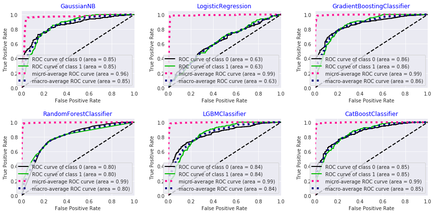

```python
plot_roc(classifiers_A,name, X_train, y_train,X_test,y_test)
```

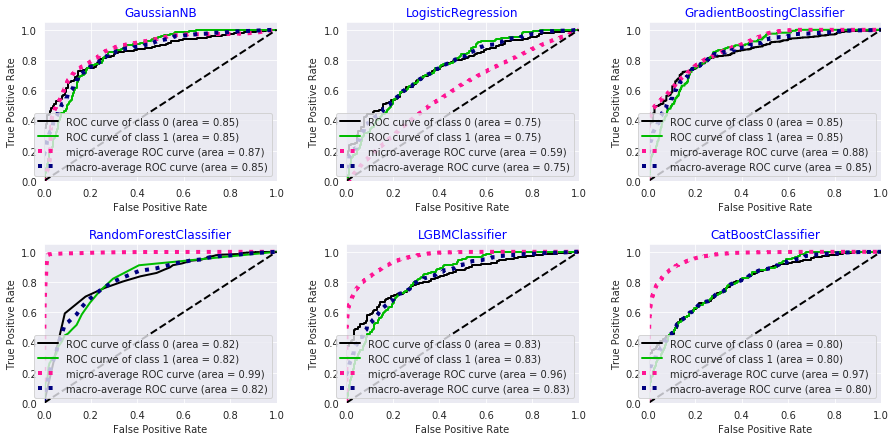

```python
plot_roc(classifiers_OV,name2, Xtrain_OV, ytrain_OV,X_test,y_test)
```

```python
def Trainsize(six_classifiers,name, X_train, y_train,X_test,y_test):

    from mlxtend.plotting import plot_learning_curves

    for cls in six_classifiers:
        cls.fit(X_train, y_train)

    plt.figure(figsize=(15,7))

    grid = plt.GridSpec(2, 3, wspace=0.3, hspace=0.4)

    for i in range(6):
        col, row = i%3,i//3
        ax = plt.subplot(grid[row,col])
        ax.title.set_text(type(six_classifiers[i]).__name__)
        ax.title.set_color('blue')

        model = six_classifiers[i]
        plot_learning_curves(X_train, y_train,
                             X_test, y_test,
                             model, print_model=False, style='ggplot')
```

### Learning_curves

Najważniejsza są informacje:

- jeżeli zbiór testowy i treningowy bardzo odstają od siebie oznacza to przeuczenie modelu
- znajduje się miejsce gdzie oba wykresy testowy i treningowy są najbliżej siebie. Dla takiej wielkości próby model działa najlepiej w kontekście przeuczenia
- na wykresie należy brać pod uwagę wielkość błędu klasyfikacji (oś y)

Dobrym wskaźnikiem przeuczenia jest różnica predykcji pomiedzy zbiorem treningowym i zbiorem testowym. W modelu GaussianNB przed oversampling występuje średni błąd wielkości 0.045. oba zbiory testowy i treningowy są blisko siebie dla każdej wielkości próby. Wpodobnie było w przypadku LogisticRegression, natomiast model GradientBoosting poprawiał swój poziom nauki wraz z wielkością próbki.

Najmniejsza różnica pomiędzy błedami zbioru treningowego i testowego dla modelu LGBMClassifier znajduje sie dla 90% zbioru treningowego.

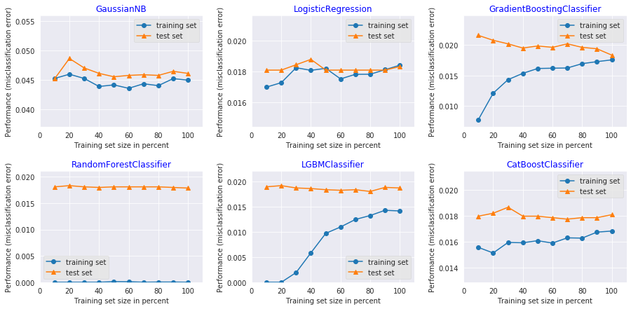

```python
Trainsize(classifiers_A,name, X_train, y_train,X_test,y_test)
```

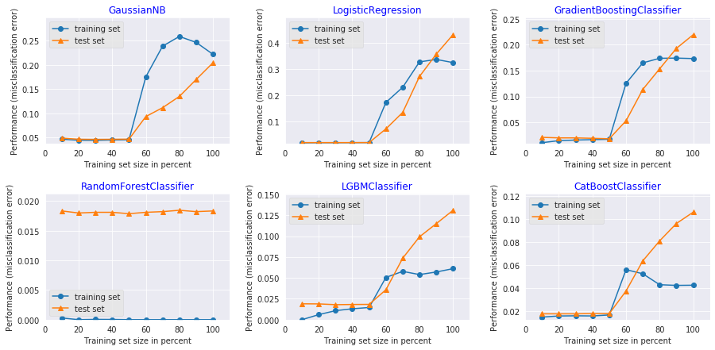

```python
Trainsize(classifiers_OV,name2, Xtrain_OV, ytrain_OV,X_test,y_test)
```

```python
y_train.dtypes
```

```
dtype('int64')
```

```python
def ks_statistic(six_classifiers,name, X_train, y_train,X_test,y_test):

    import scikitplot as skplt

    plt.figure(figsize=(15,7))
    grid = plt.GridSpec(2, 3, wspace=0.3, hspace=0.4)

    for cls in six_classifiers:
        cls.fit(X_train, y_train)

    for i in range(6):

        col, row = i%3,i//3
        ax = plt.subplot(grid[row,col])
        ax.title.set_color('blue')

        model = classifiers_A[i]
        # skplt.metrics.plot_roc(y_test, model.predict_proba(X_test), ax=ax, title=type(six_classifiers[i]).__name__)
        skplt.metrics.plot_ks_statistic(y_test, model.predict_proba(X_test), ax=ax,title=type(six_classifiers[i]).__name__)

    plt.show()
```

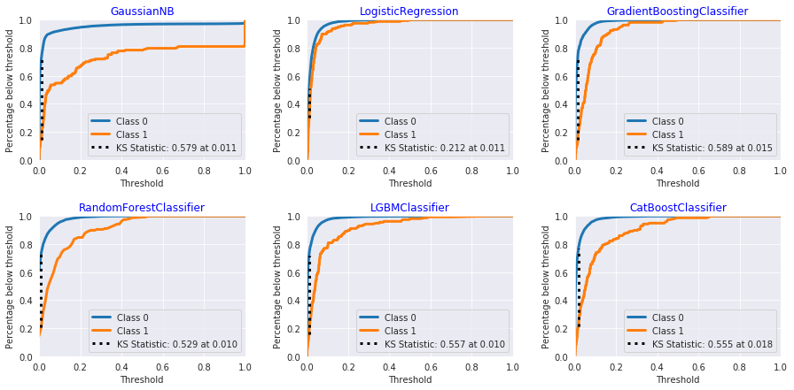

```python
ks_statistic(classifiers_A,name, X_train, y_train,X_test,y_test)
```

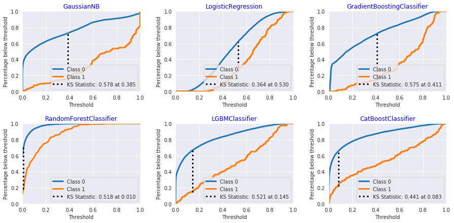

```python
ks_statistic(classifiers_OV,name2, Xtrain_OV, ytrain_OV,X_test,y_test)
```

```python
def precision_recall2(six_classifiers,name, X_train, y_train,X_test,y_test):

    import scikitplot as skplt

    plt.figure(figsize=(15,7))
    grid = plt.GridSpec(2, 3, wspace=0.3, hspace=0.4)

    for cls in six_classifiers:
        cls.fit(X_train, y_train)

    for i in range(6):

        col, row = i%3,i//3
        ax = plt.subplot(grid[row,col])
        ax.title.set_color('blue')

        model = six_classifiers[i]

        skplt.metrics.plot_precision_recall(y_test, model.predict_proba(X_test), ax=ax,title=type(six_classifiers[i]).__name__)
    plt.show()
    print(blue('Jest to krzywa łącząca precyzję (PPV) i Recall (TPR) na jednym wykresie. Im wyższa krzywa na osi y, tym lepsza wydajność modelu. Informuje, przy którym recall, precision zaczyna spadać, może pomóc wybrać próg'))
```

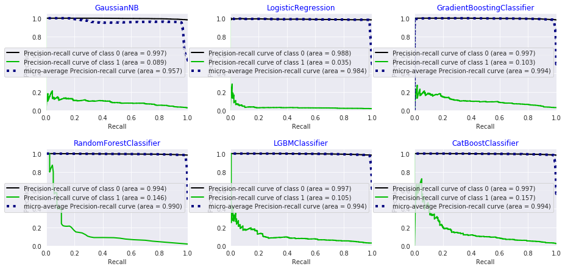

```
Jest to krzywa łącząca precyzję (PPV) i Recall (TPR) na jednym wykresie. Im wyższa krzywa na osi y, tym lepsza wydajność modelu. Informuje, przy którym recall, precision zaczyna spadać, może pomóc wybrać próg
```

```python
precision_recall2(classifiers_A,name, X_train, y_train,X_test,y_test)
```

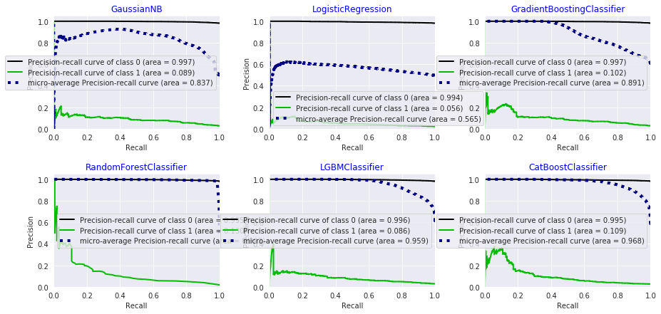

```
Jest to krzywa łącząca precyzję (PPV) i Recall (TPR) na jednym wykresie. Im wyższa krzywa na osi y, tym lepsza wydajność modelu. Informuje, przy którym recall, precision zaczyna spadać, może pomóc wybrać próg
```

```python
precision_recall2(classifiers_OV,name2, Xtrain_OV, ytrain_OV,X_test,y_test)
```

Jak widac na wykresach problemem jest precyzjia klasy 1. Nie pomogła w tym zbilansowanie zbiorów przez oversampling.

```python
def calibration_curve2(six_classifiers,name, X_train, y_train,X_test,y_test):

    import scikitplot as skplt
    from sklearn.calibration import CalibratedClassifierCV, calibration_curve

    plt.figure(figsize=(15,7))
    grid = plt.GridSpec(2, 3, wspace=0.3, hspace=0.4)

    for cls in six_classifiers:
        cls.fit(X_train, y_train)

    for i in range(6):

        col, row = i%3,i//3
        ax = plt.subplot(grid[row,col])
        ax.title.set_color('blue')



        model = classifiers_A[i]
        A_probas = model.fit(X_train, y_train).predict_proba(X_test)
        probas_list = [A_probas]

        clf_names =  [name[i]]

        skplt.metrics.plot_calibration_curve(y_test,probas_list,clf_names,title=type(six_classifiers[i]).__name__,ax=ax)

    plt.show()
```

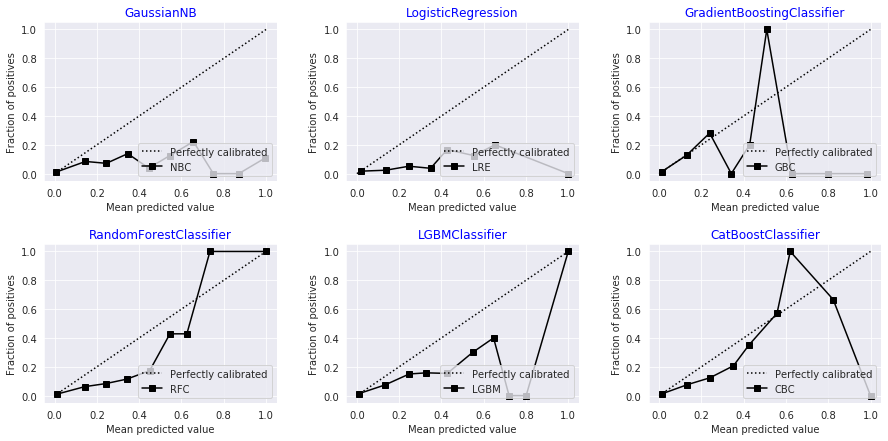

```python
calibration_curve2(classifiers_A,name, X_train, y_train,X_test,y_test)
```

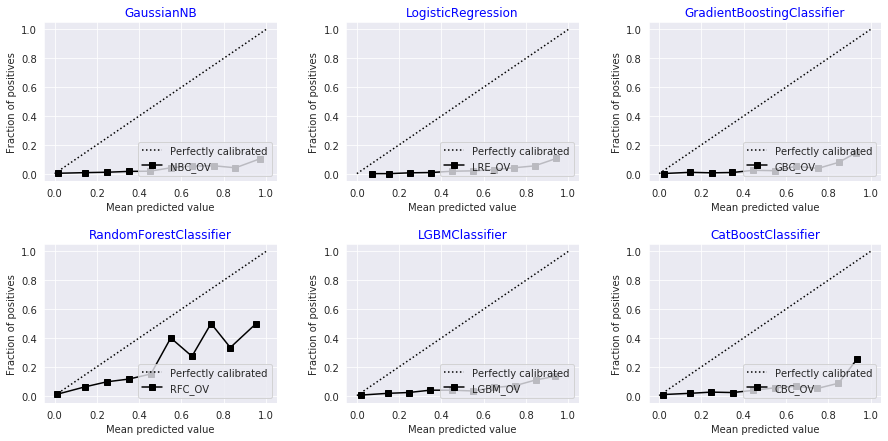

```python
calibration_curve2(classifiers_OV,name2, Xtrain_OV, ytrain_OV,X_test,y_test)
```

Wyraźnie widać, że modele nie są skalibrowane. https://machinelearningmastery.com/calibrated-classification-model-in-scikit-learn/

## Co by sie stałom gdybyśmy je teraz spróbowali skalibrować?

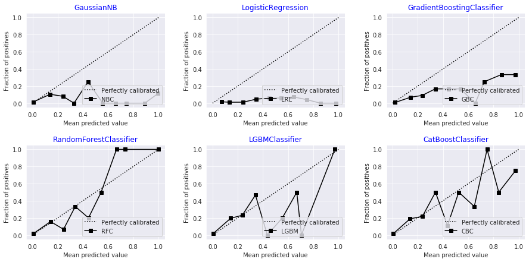

```python
from sklearn.datasets import make_classification
from sklearn.calibration import CalibratedClassifierCV
from sklearn.calibration import calibration_curve

import scikitplot as skplt
from sklearn.calibration import CalibratedClassifierCV, calibration_curve


NBC = GaussianNB()
LRE = LogisticRegression(solver='lbfgs')
GBC = GradientBoostingClassifier()
RFC = RandomForestClassifier()
LGBM = LGBMClassifier()
CBC = CatBoostClassifier(verbose=0, n_estimators=100)


classifiers_A = [NBC,LRE,GBC,RFC,LGBM,CBC]
name = ['NBC','LRE','GBC','RFC','LGBM','CBC']

#for cls in classifiers_A:
#    calibrated = CalibratedClassifierCV(cls, method='sigmoid', cv=5)
#    calibrated.fit(X_train, y_train)

plt.figure(figsize=(15,7))
grid = plt.GridSpec(2, 3, wspace=0.3, hspace=0.4)


for i in range(6):

    col, row = i%3,i//3
    ax = plt.subplot(grid[row,col])
    ax.title.set_color('blue')

    model = classifiers_A[i]
    calibrated = CalibratedClassifierCV(model, method='sigmoid', cv=5)
    calibrated.fit(X_train, y_train)
    A_probas = calibrated.fit(X_train, y_train).predict_proba(X_test)
    probas_list = [A_probas]

    clf_names =  [name[i]]

    skplt.metrics.plot_calibration_curve(y_test,probas_list,clf_names,title=type(classifiers_A[i]).__name__,ax=ax)

plt.show()
```

https://scikit-learn.org/stable/auto_examples/calibration/plot_calibration_curve.html

```python
def cumulative_gain(six_classifiers,name, X_train, y_train,X_test,y_test):

    plt.figure(figsize=(15,7))
    grid = plt.GridSpec(2, 3, wspace=0.3, hspace=0.4)

    for cls in six_classifiers:
        cls.fit(X_train, y_train)

    for i in range(6):

        col, row = i%3,i//3
        ax = plt.subplot(grid[row,col])
        ax.title.set_color('blue')

        model = six_classifiers[i]

        skplt.metrics.plot_cumulative_gain(y_test, model.predict_proba(X_test), ax=ax,title=type(six_classifiers[i]).__name__)

    plt.show()
```

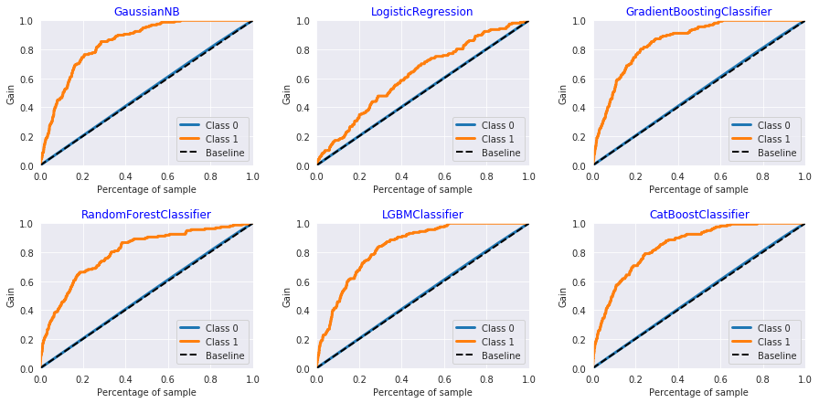

```python
cumulative_gain(classifiers_A,name, X_train, y_train,X_test,y_test)
```

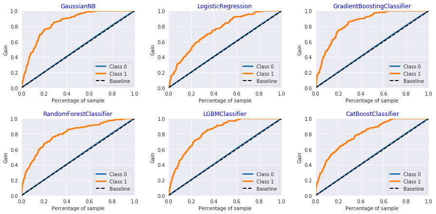

```python
cumulative_gain(classifiers_OV,name2, Xtrain_OV, ytrain_OV,X_test,y_test)
```

```python
def lift_curve(six_classifiers,name, X_train, y_train,X_test,y_test):

    plt.figure(figsize=(15,7))
    grid = plt.GridSpec(2, 3, wspace=0.3, hspace=0.4)

    for cls in six_classifiers:
        cls.fit(X_train, y_train)

    for i in range(6):

        col, row = i%3,i//3
        ax = plt.subplot(grid[row,col])
        ax.title.set_color('blue')

        model = six_classifiers[i]

        skplt.metrics.plot_lift_curve(y_test, model.predict_proba(X_test), ax=ax,title=type(six_classifiers[i]).__name__)

    plt.show()
```

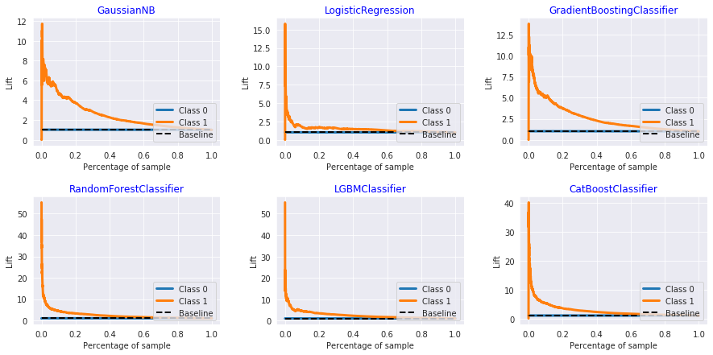

```python
lift_curve(classifiers_A,name, X_train, y_train,X_test,y_test)
```

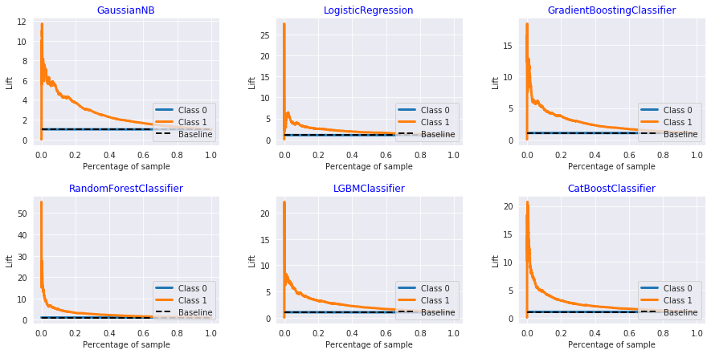

```python
lift_curve(classifiers_OV,name2, Xtrain_OV, ytrain_OV,X_test,y_test)
```

[figure not shown]